# Project Report

DAK

Author

Davis Johnson, Kaitlin Sun, Andy Wen

Published

December 5, 2022

Abstract

Health issues are something that almost everyone struggles with. By identifying risk factors and causes for different health issues (mental or physical), our team hopes to generate insights that can be used to better address them. We aim to do this by first identifying who is most at risk for suicide and if mental health resources/quality of life impacts suicide rates. Next, we want study how the working environment impacts mental health. Lastly, we want to address what day-to-day factors impact physical health. Researching these questions, we found that despite there being no strong relationship between suicide and availability of mental health resources, men and the elderly are generally at higher risk for suicide. Interventions targeting these demographics and ensuring funding for resources that have been already established is something that mental health professionals and lawmakers should prioritize. We also found that implementation of a strong mental health benefit system could benefit health in the workplace. Lastly, improving family planning and general healthcare accessibility in addition to increasing immunization rates could improve the physical health of a population.

```python
import warnings
warnings.filterwarnings("ignore")
```

```python
import pandas as pd
import numpy as np
import matplotlib.pyplot as plt
import sklearn as sk
import seaborn as sns
```

## 1 Background / Motivation

Nearly everyone struggles with or knows someone that struggles with some form of a health issue (mental or physical). We want to look into the risk factors and associations for various health problems. Our goal is to gain some insight into what is relevant/related to the health issues each of us are exploring and identifying who is most at risk. Doing so can allow us to develop ideas or solutions to address many of these health issues that people face today. The topic of mental health is especially important as it is one of the top ten health issues plaguing people today [1], yet a stigma still exists around this topic in many parts of the world. Mental health conditions aren’t always obvious and certain conditions can be hard to diagnose, making it essential to understand who is most at risk and if there are any potential associations for mental health problems with any factors.

We believe that this topic of health is one that is applicable to nearly anyone. We also believe that the insights generated can be of great use and benefit to society.

## 2 Problem statement

Davis: I aim to investigate trends relating to one of the most dire consequences of poor mental health: suicide. Specifically, I aim to investigate who is most risk for suicide utilzing a global database of suicide rates and mental health resources. I aim to find (on a global scale) if any demographics exhibit a heightened vulnerability to suicide and if an answer can be found in the availability of mental health resources.

Kaitlin: I am looking at a dataset related to mental health and specifically the employees in tech companies. I aim to investigate the relationship between the external factors that a company can provide and how they can be influencing a person’s mental health and their working performance

Andy: I’m looking into what physical factors (and general factors) in day-to-day life are most coinciding with physical illnesses and poor health in India. I want to find the socio-economic and health factors (if any) that can be used to predict increased vulnerability to health issues such as chronic illness and death.

## 3 Data sources

The data used by Davis Johnson is from one open-source link containing four different files relating to data on suicide rates and mental health resources. One dataset includes the age-standardized suicide rates for both males and females of over 150 countries, while another includes the crude suicide rates for different age groups of each country for both males and females. The other two datasets include information on the availablility of various mental health resources per 100,000 people of each country. One of these datasets includes information on human resources such as the number of psychologists per 100,000 people of each country, and the other includes information on mental health facilities such as the number of mental hospitals per 100,000 people of each country. A small issue with these two datasets is that it includes just a little over 100 countries, compared to over 150 in the previous two datasets discussed. Additionally, as the next section shows, there are several missing values for some of these variables, which can impact the validity of some of my analyses. I decided to leave these missing values as null and thus excluding them from my analyses.

data: https://www.kaggle.com/datasets/twinkle0705/mental-health-and-suicide-rates

The data used by Kaitlin Sun is from a mental status survey for tech company employees. It provides information about the objective and subjective working environment in relation to mental health suport and mental history of indiviudals of the employees. Questions in the dataset include whether mental illness has interfered with one’s work(mental history), whether the company offers space for mental illness converstaions(objective accommodation), and whether the employee feel comfortable discussing mental status with a coworker or supervisor (subjective working environment).

data: https://www.kaggle.com/datasets/osmi/mental-health-in-tech-survey?resource=download

The data used by Andy Wen is from an annual health survey conducted by India’s government in nine states, accounting for about 48 percent of the total population. This dataset has responses from thousands of respondants covering 26 key indicator topics including information about chronic illnesses, childhood diseases, and overall death rates within India. This data will allow our team to see where relationships exist between these physical health issues and everyday statistics such as household characteristics, effective literacy rate, and marraige. Doing this, we can see what (if any) datapoints are most related to the having these health issues which we can later dive deeper into.

data: https://www.kaggle.com/datasets/rajanand/key-indicators-of-annual-health-survey

## 4 Stakeholders

The result can be helpful for the average person, health experts and researchers, and lawmakers.

It will be helpful for providing insights on the importance of mental/physical care for any individual in different environments. It will make a strong argument for individuals to focus on self-care. Likewise, companies and professional environments to will be more likely to focus on offering support to their workers. Lawmakers will also be equipped with the relevant information in order to establish appropriate funding for targeted interventions that can help people with vulnerabilities. It will also give ideas on different programs that can be created to improve the health and well being of those at risk.

With medical technology becoming more and more advanced, it will be helpful for researchers to be equipped with the necessary information to conduct targeted investigations into those who exhibit the most risk factors for various health problems.

## 5 Data quality check / cleaning / preparation

##### 5.0.0.1 Davis:

For my analysis I used four separate datasets. Below is a dataset involving the age-standardized suicide rates of different countries grouped by gender (male, female, combined) for different years in the 21st century. The distrubution of age-standardized suicide rate values by y|ear column is shown below. In order to make use of this analysis, I used the pandas.melt function (as described in the EDA section) to put the year values under one column with their matching suicide rates. For the categorical variables of sex and country, no null values were detected and there were 183 countries accounted for in the dataset with three different values for Sex (Male, Female, Both Sexes) for each country. In fact, there were no null values for any variable in this dataset.

```python
age_standardized_suicide_rates = pd.read_csv('Age-standardized suicide rates.csv')
crude_suicide_rates = pd.read_csv('Crude suicide rates.csv')
facilities = pd.read_csv('Facilities.csv')
human_resources = pd.read_csv('Human Resources.csv')
```

```python
age_standardized_suicide_rates.describe()
```

|  | 2016 | 2015 | 2010 | 2000 |
| --- | --- | --- | --- | --- |
| count | 549.000000 | 549.000000 | 549.000000 | 549.000000 |
| mean | 9.792532 | 9.925683 | 10.544991 | 12.164117 |
| std | 7.469341 | 7.633241 | 8.620174 | 10.378318 |
| min | 0.000000 | 0.000000 | 0.000000 | 0.100000 |
| 25% | 4.300000 | 4.400000 | 4.700000 | 5.100000 |
| 50% | 7.900000 | 8.100000 | 8.400000 | 9.500000 |
| 75% | 13.400000 | 13.300000 | 14.100000 | 16.000000 |
| max | 48.300000 | 51.500000 | 62.300000 | 85.800000 |

| Variable | Null Values | Number of Unique Values |
| --- | --- | --- |
| Country | 0 | 183 |
| Sex | 0 | 3 |

I also used a crude suicide rates database in my analysis which also has the same categorical variable orientation as the previous database (183 unique countries, 3 different values of sex for each country). Instead of having years as the continuous variable columns, this dataset uses different age ranges as the columns with the crude suicide rates for each country and that age range under the column. There are also no missing values in this dataset. For my analysis, I again employed the pandas.melt function to file all of the age ranges under one column and their matching crude suicide rates in another column. That process is described in the EDA.

```python
crude_suicide_rates.describe()
```

|  | 80_above | 70to79 | 60to69 | 50to59 | 40to49 | 30to39 | 20to29 | 10to19 |
| --- | --- | --- | --- | --- | --- | --- | --- | --- |
| count | 549.000000 | 549.000000 | 549.000000 | 549.000000 | 549.000000 | 549.000000 | 549.000000 | 549.000000 |
| mean | 42.585428 | 25.936794 | 17.439162 | 14.743352 | 12.189435 | 10.895446 | 10.423315 | 4.075046 |
| std | 43.477900 | 24.795457 | 14.315504 | 12.790041 | 11.121364 | 10.148280 | 9.051273 | 3.393507 |
| min | 0.000000 | 0.000000 | 0.000000 | 0.000000 | 0.000000 | 0.000000 | 0.000000 | 0.000000 |
| 25% | 13.600000 | 8.400000 | 6.600000 | 5.600000 | 4.800000 | 4.300000 | 4.300000 | 1.700000 |
| 50% | 26.600000 | 17.100000 | 12.900000 | 11.200000 | 9.000000 | 8.000000 | 7.900000 | 3.100000 |
| 75% | 55.500000 | 35.800000 | 24.000000 | 20.000000 | 16.400000 | 13.900000 | 13.500000 | 5.300000 |
| max | 285.000000 | 133.700000 | 78.500000 | 85.400000 | 86.500000 | 88.400000 | 57.400000 | 24.200000 |

| Variable | Null Values | Number of Unique Values |
| --- | --- | --- |
| Country | 0 | 183 |
| Sex | 0 | 3 |

I also utilized two other datasets which detail the number of human resources and mental health facilities per 100,000 people of each country in 2016. As shown below, there are several missing values relating to the continous variables, with data on residential_facilties being the most lacking. It was unclear if missing values translated to an absence of such resources or simply missing data, but I decided to keep it as missing for the sake of this analysis. It is also worth noting that both these datasets don’t contain near the same amount of countries as the previous two, which is something to note when I try to find associations between mental health resources and suicide rates later in the analysis.

```python
facilities.describe()
```

|  | Year | Mental _hospitals | health_units | outpatient _facilities | day _treatment | residential_facilities |
| --- | --- | --- | --- | --- | --- | --- |
| count | 112.0 | 90.000000 | 102.000000 | 100.000000 | 51.000000 | 45.000000 |
| mean | 2016.0 | 0.246133 | 0.319078 | 1.875130 | 1.134804 | 0.873311 |
| std | 0.0 | 0.910416 | 0.618220 | 3.227911 | 2.725713 | 1.609117 |
| min | 2016.0 | 0.000000 | 0.006000 | 0.006000 | 0.002000 | 0.006000 |
| 25% | 2016.0 | 0.018250 | 0.035750 | 0.123500 | 0.022500 | 0.033000 |
| 50% | 2016.0 | 0.036500 | 0.093500 | 0.573000 | 0.125000 | 0.152000 |
| 75% | 2016.0 | 0.158750 | 0.379000 | 2.236000 | 0.760500 | 0.479000 |
| max | 2016.0 | 8.314000 | 4.542000 | 19.751000 | 17.176000 | 6.178000 |

| Variable | Null Values | Number of Unique Values |
| --- | --- | --- |
| Country | 0 | 112 |
| Year | 0 | 1 |

```python
human_resources.describe()
```

|  | Year | Psychiatrists | Nurses | Social_workers | Psychologists |
| --- | --- | --- | --- | --- | --- |
| count | 107.0 | 104.000000 | 91.000000 | 68.000000 | 84.000000 |
| mean | 2016.0 | 4.340519 | 12.122934 | 4.832632 | 10.415345 |
| std | 0.0 | 7.645392 | 22.869974 | 16.902273 | 31.451687 |
| min | 2016.0 | 0.007000 | 0.000000 | 0.006000 | 0.000000 |
| 25% | 2016.0 | 0.219750 | 0.793500 | 0.066500 | 0.236750 |
| 50% | 2016.0 | 1.231000 | 4.199000 | 0.375500 | 1.139000 |
| 75% | 2016.0 | 4.559500 | 10.952500 | 1.351250 | 5.150250 |
| max | 2016.0 | 48.040000 | 150.251000 | 102.592000 | 222.572000 |

| Variable | Null Values | Number of Unique Values |
| --- | --- | --- |
| Country | 0 | 107 |
| Sex | 0 | 1 |

##### 5.0.0.2 Kaitlin:

```python
mental_survey = pd.read_csv('survey.csv')
```

```python
mental_survey.info()
```

[output not shown]

[output cut: 21 more lines]

For columns with too many missing values (comments) or unrelated to the result (state), the variable was deleted. Moreover, I transfer the response levels (always, often, sometimes, rarely, never) into numerical scores for analysis, which whill be shown below.

##### 5.0.0.3 Andy:

For my analysis, I used one dataset that polled 9 Indian states that account for 48% of the population on different health statistics from 2012-2013. The data looks at these 9 Indian states and has information about 26 key indicators (household characteristics, chronic illnesses, immunization rates, etc.). This information is normalized by population (and broken up by region (rural or urban) and sex (male and female). Each of these 26 key indicators are made up of several other questions/statistics totaling 642, all of which are continuous variables. The distribution of these 642 variables are shown below:

```python
import pandas as pd

# import data into indicators
indicators = pd.read_csv('Key_indicator_statewise.csv')
indicators.describe()
```

|  | AA_Sample_Units_Total | AA_Sample_Units_Rural | AA_Sample_Units_Urban | AA_Households_Total | AA_Households_Rural | AA_Households_Urban | AA_Population_Total | AA_Population_Rural | AA_Population_Urban | AA_Ever_Married_Women_Aged_15_49_Years_Total | ... | ZZ_Under_Five_Mortality_Rate_U5MR_Rural_Lower_Limit | ZZ_Under_Five_Mortality_Rate_U5MR_Rural_Upper_Limit | ZZ_Under_Five_Mortality_Rate_U5MR_Urban_Lower_Limit | ZZ_Under_Five_Mortality_Rate_U5MR_Urban_Upper_Limit | ZZ_Sex_Ratio_At_Birth_Total_Lower_Limit | ZZ_Sex_Ratio_At_Birth_Total_Upper_Limit | ZZ_Sex_Ratio_At_Birth_Rural_Lower_Limit | ZZ_Sex_Ratio_At_Birth_Rural_Upper_Limit | ZZ_Sex_Ratio_At_Birth_Urban_Lower_Limit | ZZ_Sex_Ratio_At_Birth_Urban_Upper_Limit |
| --- | --- | --- | --- | --- | --- | --- | --- | --- | --- | --- | --- | --- | --- | --- | --- | --- | --- | --- | --- | --- | --- |
| count | 9.000000 | 9.000000 | 9.000000 | 9.000000 | 9.000000 | 9.000000 | 9.000000e+00 | 9.000000e+00 | 9.000000 | 9.000000 | ... | 9.000000 | 9.000000 | 9.000000 | 9.000000 | 9.000000 | 9.000000 | 9.000000 | 9.000000 | 9.000000 | 9.000000 |
| mean | 2299.222222 | 1703.111111 | 596.111111 | 479684.333333 | 389075.222222 | 90609.111111 | 2.340752e+06 | 1.909673e+06 | 431078.333333 | 442178.525556 | ... | 73.333333 | 76.111111 | 43.111111 | 48.777778 | 907.111111 | 926.777778 | 910.000000 | 931.444444 | 881.000000 | 931.444444 |
| std | 738.802372 | 525.746004 | 266.659635 | 179108.137044 | 152837.981905 | 45610.159061 | 1.071480e+06 | 9.173469e+05 | 241392.050217 | 175654.782983 | ... | 15.182226 | 15.086786 | 11.151731 | 10.917621 | 26.708821 | 27.160531 | 26.167728 | 26.524098 | 35.298725 | 42.338254 |
| min | 1255.000000 | 926.000000 | 329.000000 | 287085.000000 | 226554.000000 | 44654.000000 | 1.264309e+06 | 9.944160e+05 | 233961.000000 | 251943.000000 | ... | 50.000000 | 53.000000 | 27.000000 | 31.000000 | 861.000000 | 884.000000 | 868.000000 | 894.000000 | 823.000000 | 877.000000 |
| 25% | 1841.000000 | 1412.000000 | 375.000000 | 388853.000000 | 308474.000000 | 62365.000000 | 1.809610e+06 | 1.518639e+06 | 290971.000000 | 349930.000000 | ... | 63.000000 | 67.000000 | 34.000000 | 40.000000 | 897.000000 | 914.000000 | 895.000000 | 918.000000 | 860.000000 | 904.000000 |
| 50% | 2356.000000 | 1660.000000 | 547.000000 | 392734.000000 | 319766.000000 | 74592.000000 | 1.992799e+06 | 1.629355e+06 | 355647.000000 | 385476.000000 | ... | 76.000000 | 79.000000 | 45.000000 | 51.000000 | 915.000000 | 928.000000 | 918.000000 | 933.000000 | 874.000000 | 920.000000 |
| 75% | 2501.000000 | 1962.000000 | 595.000000 | 519811.000000 | 392913.000000 | 84169.000000 | 2.389787e+06 | 1.644036e+06 | 375262.000000 | 471826.410000 | ... | 79.000000 | 82.000000 | 48.000000 | 55.000000 | 920.000000 | 940.000000 | 930.000000 | 954.000000 | 893.000000 | 953.000000 |
| max | 3927.000000 | 2782.000000 | 1145.000000 | 883613.000000 | 710313.000000 | 173300.000000 | 4.808503e+06 | 3.883293e+06 | 925210.000000 | 835022.320000 | ... | 96.000000 | 98.000000 | 61.000000 | 65.000000 | 943.000000 | 969.000000 | 944.000000 | 973.000000 | 945.000000 | 1009.000000 |

8 rows × 642 columns

There weren’t any categorical variables apart from the state names, of which there were 9 unique values and none of which are null as can be seen below. All of these values only occurred once each.

```python
indicators.loc[: , ["State_Name"]].info()
```

```
<class 'pandas.core.frame.DataFrame'>
RangeIndex: 9 entries, 0 to 8
Data columns (total 1 columns):
 #   Column      Non-Null Count  Dtype
---  ------      --------------  -----
 0   State_Name  9 non-null      object
dtypes: object(1)
memory usage: 200.0+ bytes
```

There didn’t seem to be any incorrect values that required cleaning throughout the analysis and there weren’t any null values as shown below which scans each of the 9 rows for any missing values. Since they all came out as False, we know that there aren’t any missing values.

```python
indicators.isnull().any(axis=1)
```

```
0    False
1    False
2    False
3    False
4    False
5    False
6    False
7    False
8    False
dtype: bool
```

The only data preparation that was needed was the breakdown of the larger dataset into smaller dataframe components covering each of the 26 key indicators. An example of this is shown below where I create a dataframe only including those related to the Chronic Illness Key Indicator:

```python
# Chronic Illness Key Indicator
chronic_illness = indicators.iloc[: , [0] + [i for i in range(199, 289)]]
chronic_illness.describe()
```

|  | KK_Having_Any_Kind_Of_Symptoms_Of_Chronic_Illness_Per_100000_Population_Person_Total | KK_Having_Any_Kind_Of_Symptoms_Of_Chronic_Illness_Per_100000_Population_Person_Rural | KK_Having_Any_Kind_Of_Symptoms_Of_Chronic_Illness_Per_100000_Population_Person_Urban | KK_Having_Any_Kind_Of_Symptoms_Of_Chronic_Illness_Per_100000_Population_Male_Total | KK_Having_Any_Kind_Of_Symptoms_Of_Chronic_Illness_Per_100000_Population_Male_Rural | KK_Having_Any_Kind_Of_Symptoms_Of_Chronic_Illness_Per_100000_Population_Male_Urban | KK_Having_Any_Kind_Of_Symptoms_Of_Chronic_Illness_Per_100000_Population_Female_Total | KK_Having_Any_Kind_Of_Symptoms_Of_Chronic_Illness_Per_100000_Population_Female_Rural | KK_Having_Any_Kind_Of_Symptoms_Of_Chronic_Illness_Per_100000_Population_Female_Urban | KK_Having_Any_Kind_Of_Symptoms_Of_Chronic_Illness_And_Sought_Medical_Care_Person_Total | ... | KK_Having_Diagnosed_For_Any_Kind_Of_Chronic_Illness_And_Getting_Regular_Treatment_Female_Urban | KK_Having_Diagnosed_For_Any_Kind_Of_Chronic_Illness_And_Getting_Regular_Treatment_From_Government_Source_Person_Total | KK_Having_Diagnosed_For_Any_Kind_Of_Chronic_Illness_And_Getting_Regular_Treatment_From_Government_Source_Person_Rural | KK_Having_Diagnosed_For_Any_Kind_Of_Chronic_Illness_And_Getting_Regular_Treatment_From_Government_Source_Person_Urban | KK_Having_Diagnosed_For_Any_Kind_Of_Chronic_Illness_And_Getting_Regular_Treatment_From_Government_Source_Male_Total | KK_Having_Diagnosed_For_Any_Kind_Of_Chronic_Illness_And_Getting_Regular_Treatment_From_Government_Source_Male_Rural | KK_Having_Diagnosed_For_Any_Kind_Of_Chronic_Illness_And_Getting_Regular_Treatment_From_Government_Source_Male_Urban | KK_Having_Diagnosed_For_Any_Kind_Of_Chronic_Illness_And_Getting_Regular_Treatment_From_Government_Source_Female_Total | KK_Having_Diagnosed_For_Any_Kind_Of_Chronic_Illness_And_Getting_Regular_Treatment_From_Government_Source_Female_Rural | KK_Having_Diagnosed_For_Any_Kind_Of_Chronic_Illness_And_Getting_Regular_Treatment_From_Government_Source_Female_Urban |
| --- | --- | --- | --- | --- | --- | --- | --- | --- | --- | --- | --- | --- | --- | --- | --- | --- | --- | --- | --- | --- | --- |
| count | 9.000000 | 9.000000 | 9.000000 | 9.000000 | 9.000000 | 9.000000 | 9.000000 | 9.000000 | 9.000000 | 9.000000 | ... | 9.000000 | 9.000000 | 9.000000 | 9.000000 | 9.000000 | 9.000000 | 9.000000 | 9.000000 | 9.000000 | 9.000000 |
| mean | 9800.867778 | 9662.198889 | 10088.351111 | 8762.744444 | 8639.782222 | 9024.345556 | 10873.597778 | 10699.387778 | 11251.154444 | 88.671111 | ... | 70.650000 | 30.581111 | 31.427778 | 28.010000 | 31.082222 | 32.083333 | 28.258889 | 30.150000 | 30.810000 | 27.765556 |
| std | 4269.009833 | 4447.846892 | 3787.108572 | 3875.802979 | 4004.710070 | 3616.574291 | 4719.290792 | 4944.801263 | 4026.528978 | 5.100040 | ... | 8.168395 | 15.462667 | 16.426012 | 13.093496 | 15.098911 | 16.173130 | 12.446749 | 15.789043 | 16.599719 | 13.666399 |
| min | 4176.200000 | 3842.350000 | 5326.000000 | 4019.780000 | 3740.820000 | 4678.000000 | 4337.400000 | 3946.470000 | 5811.820000 | 80.500000 | ... | 53.100000 | 9.200000 | 8.800000 | 11.900000 | 10.000000 | 9.700000 | 12.100000 | 8.600000 | 8.100000 | 11.800000 |
| 25% | 6826.090000 | 6672.390000 | 7152.340000 | 6158.910000 | 6105.310000 | 6271.990000 | 7554.920000 | 7289.310000 | 8122.540000 | 85.200000 | ... | 66.790000 | 15.560000 | 15.550000 | 17.600000 | 16.600000 | 16.600000 | 18.800000 | 14.720000 | 14.710000 | 16.500000 |
| 50% | 10356.800000 | 10087.930000 | 10990.610000 | 8473.550000 | 8143.010000 | 9385.460000 | 11290.070000 | 11138.880000 | 12137.000000 | 89.900000 | ... | 70.200000 | 30.160000 | 32.970000 | 26.330000 | 31.490000 | 34.160000 | 26.620000 | 28.890000 | 31.830000 | 26.540000 |
| 75% | 12257.760000 | 12632.890000 | 11061.000000 | 10667.410000 | 11062.300000 | 9655.000000 | 13926.790000 | 14250.500000 | 12785.700000 | 91.850000 | ... | 77.630000 | 40.000000 | 41.200000 | 35.100000 | 40.000000 | 41.400000 | 34.200000 | 40.000000 | 40.900000 | 35.290000 |
| max | 17413.000000 | 17366.000000 | 17627.000000 | 16263.000000 | 16168.000000 | 16686.000000 | 18608.000000 | 18605.000000 | 18623.000000 | 95.310000 | ... | 79.200000 | 53.000000 | 53.770000 | 54.700000 | 52.800000 | 54.090000 | 53.100000 | 53.300000 | 53.480000 | 56.000000 |

8 rows × 90 columns

## 6 Exploratory Data Analysis

### 6.1 Question 1: Who is most at risk for suicide? Is the availability of mental health resources associated with suicide risk across the globe?

*By Davis Johnson*

In this question, I attempted to analyze general suicide trends across the world through the 21st century up to 2016. The “Age-standardized suicide rates” datasets was used for the purposes of this analysis as it is the only dataset I used that had suicide rates for multiple years. Additionally, having the suicide rates be provided as age-standardized is useful in order to compare suicide rates across country and sex because the age composition of each country can greatly differ in both size and distribution. Additionally, this helps protect against these different age distributions from influencing the overall suicide rate of the country.

```python
import pandas as pd
import matplotlib.pyplot as plt
import seaborn as sns
```

```python
import os
os.chdir('/Users/davisjohnson/Documents/STAT_303_In_Class_Exercises/archive')
```

```python
age_standardized_suicide_rates = pd.read_csv('Age-standardized suicide rates.csv')
```

```python
age_standardized_suicide_rates.head(3)
```

|  | Country | Sex | 2016 | 2015 | 2010 | 2000 |
| --- | --- | --- | --- | --- | --- | --- |
| 0 | Afghanistan | Both sexes | 6.4 | 6.6 | 7.4 | 8.1 |
| 1 | Afghanistan | Male | 10.6 | 10.9 | 12.5 | 14.3 |
| 2 | Afghanistan | Female | 2.1 | 2.1 | 2.1 | 1.7 |

To conduct the analysis, I subsetted the data to only include “Sex” columns with either male or female in order to have the ability to compare genders. I also reorganized the data to start with the year 2000 and removed the “2015” column to allow for more even spacing between data points on the upcoming visualization. In order to create subgroups, I decided to create a new column that included the continent for each country listed in the database by importing a list of countries for each continent and using a lambda function to import the continent name for each country. This was used to create different lineplots comparing suicide rates over time for males and females by continent.

```python
age_standardized_suicide_rates = age_standardized_suicide_rates[['Country', 'Sex', '2000', '2010', '2015','2016']]
```

```python
age_standardized_suicide_rates = age_standardized_suicide_rates.drop(columns=['2015'])
```

```python
Asian_countries = ['Kazakhstan', 'Kyrgyzstan', 'Tajikistan', 'Turkmenistan', 'Uzbekistan',
                  'China', "Democratic People's Republic of Korea", 'Japan', 'Mongolia',
                   'Republic of Korea', 'Afghanistan', 'Bangladesh', 'Bhutan', 'India',
                   'Iran (Islamic Republic of)', 'Maldives', 'Nepal', 'Pakistan',
                    'Sri Lanka', 'Brunei Darussalam', 'Cambodia', 'Indonesia', "Lao People's Democratic Republic",
                   'Malaysia', 'Myanmar', 'Philippines', 'Singapore', 'Thailand', 'Timor-Leste', 'Viet Nam',
                   'Armenia', 'Azerbaijan', 'Bahrain', 'Cyprus', 'Georgia', 'Iraq', 'Israel', 'Jordan', 'Kuwait',
                   'Lebanon', 'Oman', 'Qatar', 'Saudi Arabia', 'State of Palestine', 'Syrian Arab Republic',
                   'Turkey', 'United Arab Emirates', 'Yemen']
African_countries = ['Algeria','Angola','Benin','Botswana','Burkina Faso','Burundi','Cabo Verde','Cameroon',
                    'Central African Republic','Chad','Comoros','Congo',"Côte d'Ivoire",'Djibouti',
                    'Democratic Republic of the Congo','Egypt','Equatorial Guinea','Eritrea','Eswatini',
                    'Ethiopia','Gabon','Gambia','Ghana','Guinea','Guinea-Bissau','Kenya','Lesotho','Liberia','Libya',
                    'Madagascar','Malawi','Mali','Mauritania','Mauritius','Morocco','Mozambique','Namibia','Niger',
                    'Nigeria','Rwanda','Sao Tome and Principe','Senegal','Seychelles','Sierra Leone','Somalia',
                    'South Africa','South Sudan','Sudan','United Republic of Tanzania','Togo','Tunisia','Uganda','Zambia','Zimbabwe']
North_American_countries = ['Antigua and Barbuda','Bahamas','Barbados','Belize','Canada','Costa Rica','Cuba',
                           'Dominica','Dominican Republic','El Salvador','Grenada','Guatemala','Haiti','Honduras',
                           'Jamaica','Mexico','Nicaragua','Panama','Saint Kitts and Nevis','Saint Lucia',
                           'Saint Vincent and the Grenadines','Trinidad and Tobago','United States of America']
South_American_countries = ['Argentina','Bolivia (Plurinational State of)','Brazil','Chile','Colombia','Ecuador','Guyana','Paraguay',
                           'Peru','Suriname','Uruguay','Venezuela (Bolivarian Republic of)']
European_countries = ['Albania','Andorra','Austria','Belarus','Belgium','Bosnia and Herzegovina','Bulgaria',
                     'Croatia','Czechia','Denmark','Estonia','Finland','France','Germany','Greece',
                     'Hungary','Iceland','Ireland','Italy','Latvia','Liechtenstein','Lithuania','Luxembourg',
                     'Malta','Republic of Moldova','Monaco','Montenegro','Netherlands','Republic of North Macedonia','Norway','Poland',
                     'Portugal','Romania','Russian Federation','San Marino','Serbia','Slovakia','Slovenia','Spain','Sweden',
                     'Switzerland','Ukraine','United Kingdom of Great Britain and Northern Ireland','Vatican City']
Oceania_countries = ['Australia','Fiji','Kiribati','Marshall Islands','Micronesia (Federated States of)','Nauru','New Zealand','Palau',
                    'Papua New Guinea','Samoa','Solomon Islands','Tonga','Tuvalu','Vanuatu']
```

```python
age_standardized_suicide_rates['Continent'] = age_standardized_suicide_rates['Country'].apply(lambda x: 'Asia' if x in Asian_countries
                                                else 'Africa' if x in African_countries
                                                else 'North America' if x in North_American_countries
                                                else 'South America' if x in South_American_countries
                                                else 'Europe' if x in European_countries
                                                else 'Oceania' if x in Oceania_countries
                                                else 'no continent')
```

```python
age_standardized_male_female = age_standardized_suicide_rates.loc[age_standardized_suicide_rates['Sex'] != ' Both sexes',:]
```

```python
age_standardized_male_female.head(3)
```

|  | Country | Sex | 2000 | 2010 | 2016 | Continent |
| --- | --- | --- | --- | --- | --- | --- |
| 1 | Afghanistan | Male | 14.3 | 12.5 | 10.6 | Asia |
| 2 | Afghanistan | Female | 1.7 | 2.1 | 2.1 | Asia |
| 4 | Albania | Male | 8.2 | 9.5 | 7.0 | Europe |

However, I ran into a small problem trying to create the lineplots with the existing dataset structure because each year is represented as a separate column, making it difficult to compare change over time. To solve this problem, I used the pandas.melt function to place the years under one “Year” column with their matching suicide rate.

```python
age_standardized_male_female = age_standardized_male_female.melt(id_vars=["Country", "Sex", "Continent"],
        var_name="Year",
        value_name="Standardized Suicide Rate")
```

```python
age_standardized_male_female.head(2)
```

|  | Country | Sex | Continent | Year | Standardized Suicide Rate |
| --- | --- | --- | --- | --- | --- |
| 0 | Afghanistan | Male | Asia | 2000 | 14.3 |
| 1 | Afghanistan | Female | Asia | 2000 | 1.7 |

I then created a lineplot FacetGrid comparing suicide rates over time for males and females separately, grouped by continent. I have to note that these lineplots include the average suicide rates for each sex/continent for each given year, which creates some large variances in confidence intervals for continents with more suicide rate variance between countries.

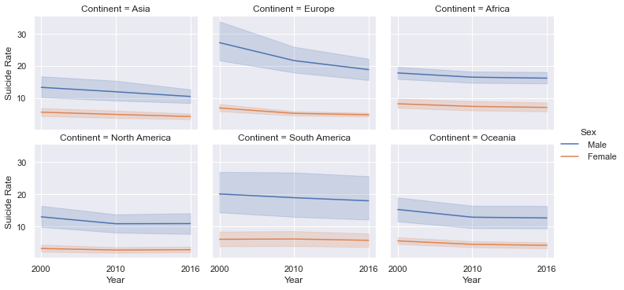

```python
suicide_lineplot = sns.FacetGrid(age_standardized_male_female, hue = 'Sex', col = 'Continent',col_wrap=3,height=3.5,aspect = 1)
suicide_lineplot.map(sns.lineplot,'Year','Standardized Suicide Rate')
suicide_lineplot.set_axis_labels("Year", "Suicide Rate")
suicide_lineplot.figure.set_size_inches(10, 5)
suicide_lineplot.add_legend()
```

As the visualization shows, suicide rates for each gender and continent are generally decreasing across the 21st century or remaining relatively stable. However, one key aspect is that male suicide rates are, on average, significantly higher than female suicide rates. Some insight on potential explanations are given later.

I next examined the “Crude suicide rates” dataset to gain some more insight into the association of age with suicide rates, instead of just a general trend of suicide rates over time. This dataset provides the crude suicide rates of each country for both sexes, with columns for different age ranges.

```python
crude_suicide_rates = pd.read_csv('Crude suicide rates.csv')
crude_suicide_rates.head(3)
```

|  | Country | Sex | 80_above | 70to79 | 60to69 | 50to59 | 40to49 | 30to39 | 20to29 | 10to19 |
| --- | --- | --- | --- | --- | --- | --- | --- | --- | --- | --- |
| 0 | Afghanistan | Both sexes | 42.0 | 11.0 | 5.5 | 5.6 | 6.6 | 9.2 | 10.2 | 3.1 |
| 1 | Afghanistan | Male | 70.4 | 20.9 | 9.8 | 9.3 | 10.5 | 15.1 | 16.3 | 4.8 |
| 2 | Afghanistan | Female | 20.1 | 2.3 | 1.4 | 1.6 | 2.3 | 2.7 | 3.5 | 1.2 |

For this dataset, I applied the same lambda function from the previous analysis to add a continent column for each country, while also subsetting the data to include columns to exlclude rows where the value of the “Sex” column is “Both sexes”. I also applied the pandas.melt function to put all the age bin columns under one column in order to execute the upcoming visualization.

```python
crude_suicide_rates['Continent'] = crude_suicide_rates['Country'].apply(lambda x: 'Asia' if x in Asian_countries
                                                else 'Africa' if x in African_countries
                                                else 'North America' if x in North_American_countries
                                                else 'South America' if x in South_American_countries
                                                else 'Europe' if x in European_countries
                                                else 'Oceania' if x in Oceania_countries
                                                else 'no continent')
```

```python
crude_suicide_rates = crude_suicide_rates.melt(id_vars=["Country", "Sex", "Continent"],
        var_name="Age Bin",
        value_name="Crude Suicide Rate")
```

```python
crude_male_female = crude_suicide_rates.loc[crude_suicide_rates['Sex'] != ' Both sexes',:]
```

```python
crude_male_female.head(2)
```

|  | Country | Sex | Continent | Age Bin | Crude Suicide Rate |
| --- | --- | --- | --- | --- | --- |
| 1 | Afghanistan | Male | Asia | 80_above | 70.4 |
| 2 | Afghanistan | Female | Asia | 80_above | 20.1 |

I then executed another FacetGrid to create barplots comparing average crude suicide rates for each age category, grouped by both gender and continent.

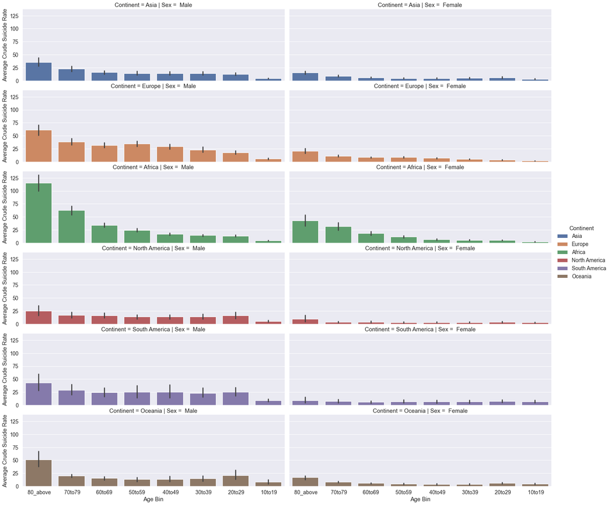

```python
sns.set(font_scale=1.25)
crude_barplots = sns.FacetGrid(crude_male_female,col='Sex',height = 5,aspect = 3, row='Continent',hue='Continent')
crude_barplots.map(sns.barplot, 'Age Bin' , 'Crude Suicide Rate')
crude_barplots.set_axis_labels("Age Bin", "Average Crude Suicide Rate")
crude_barplots.figure.set_size_inches(20, 18)
crude_barplots.add_legend()
```

In this figure, the general difference in suicide rates for men and women from the same continent and age groups is similar to what the first visualization illustrates. However, an additional insight I gained from this analysis is that older age groups generally have higher rates of suicide regardless of country or gender. Some research on potential explanations is presented in a later section.

To gain some insight into if the availability of mental health resources (both human resources and facilities), I merged the “Facilities” and “Human Resources” datasets with two seperate subsetted datasets from the “Age-standardized suicide rates”, matching by country. These subsets included only the 2016 age-standardized suicide rates for each country, with one dataset only including male data and the other including only female data. I then generated a heatmap for each dataset to find any association between standardized suicide rates and mental health resource availability (per 100,000 people of a country’s population).

```python
age_standardized_female = age_standardized_male_female.loc[age_standardized_male_female['Sex'] == ' Female',:]
age_standardized_male = age_standardized_male_female.loc[age_standardized_male_female['Sex'] == ' Male',:]
```

```python
age_standardized_male['Year'] = pd.to_numeric(age_standardized_male['Year'], downcast = 'integer', errors = 'coerce')
age_standardized_male_2016 = age_standardized_male.loc[age_standardized_male['Year'] == 2016,:]
age_standardized_female['Year'] = pd.to_numeric(age_standardized_female['Year'], downcast = 'integer', errors = 'coerce')
age_standardized_female_2016 = age_standardized_female.loc[age_standardized_female['Year'] == 2016,:]
```

```python
facilities = pd.read_csv('Facilities.csv')
human_resources = pd.read_csv('Human Resources.csv')
```

```python
male_2016_resources = pd.merge(age_standardized_male_2016,human_resources)
female_2016_resources = pd.merge(age_standardized_female_2016,human_resources)
```

```python
male_2016_facilities = pd.merge(male_2016_resources, facilities)
female_2016_facilities = pd.merge(female_2016_resources,facilities)
```

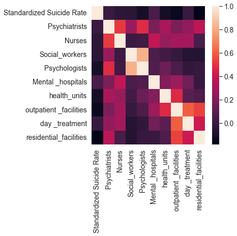

```python
fig, ax = plt.subplots(figsize=(5,5))
sns.heatmap(female_2016_facilities.iloc[:,4:].corr())
```

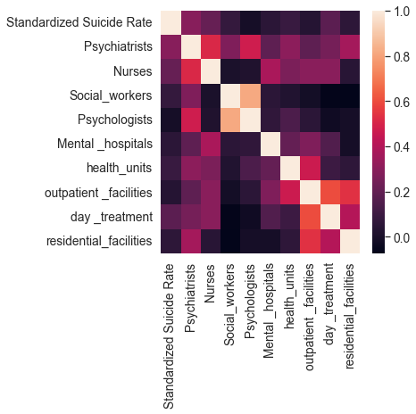

```python
fig, ax = plt.subplots(figsize=(5,5))
sns.heatmap(male_2016_facilities.iloc[:,4:].corr())
```

Unfortunately, there appears to be no discernable association between mental health resource availability and standardized suicide rate on a global scale. Further implications are discussed in the Conclusions and Recommendations sections.

### 6.2 Question 2: What are some potential benefits a company can offer for their employees to support their mental status? How do people perceive the importance of mental health in the working environment?

*By Kaitlin Sun*

In the initial stage, I cleaned the dataset in the following steps: 1) I dropped the string information that has over 80% of null input - comment; then, I also dropped the “state” column which has a lot of NaN and is not related to the analysis

2. there are some age data that are out of the common range (i.e. 9999) so I limited the range for age to 0-100

```python
#data cleaning
mental_survey.drop(['comments'],axis=1,inplace=True)
mental_survey.drop(['state'],axis=1,inplace=True)
mental_survey.Gender.value_counts()

count = 0
mental_survey['gender_cleaned'] = 'na'
for i in mental_survey['Gender']:
    if 'Neuter' in i or 'queer' in i or 'Androgyne' in i or 'Agender' in i or 'Enby' in i or 'queer' in i or 'non-binary' in i or 'fluid' in i or 'Genderqueer' in i:
        mental_survey['gender_cleaned'][count] = 'queer'
    elif 'F' in i or 'f' in i or 'she' in i or 'oman' in i:
        mental_survey['gender_cleaned'][count] = 'female'
    else:
        mental_survey['gender_cleaned'][count] = 'male'
    count += 1
```

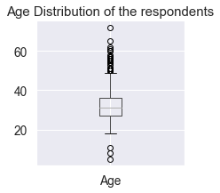

```python
mental_survey = mental_survey[mental_survey['Age'] <= 100]
mental_survey = mental_survey[mental_survey['Age'] > 0]
fig, ax = plt.subplots(figsize=(3,3))
mental_survey.boxplot(column = 'Age')
plt.title("Age Distribution of the respondents");
```

Because there are so many columns and information, I decided to put them into categories based on my question and hypothesis the first category is the dependent variable, which is a person’s mental health. To do so, I combined the treatment, family history, and work_interfere column: if a person has had treatment, we expect that s/he has experience a certain degree of mental illness, which is a score of 3; and depending on how often the symptom affect one’s work, there are three four levels of severity. If a person has family history of mental illness, then we would expect that some of the mental health status is unrelated to the working environment, thus 2 points is subtracted. All information combined is the dependent variable: the mental illness score.

```python
#dependent variable: mental illness score the lower the better
mental_survey['work_interfere'] = mental_survey['work_interfere'].replace(np.nan, 'Rarely' )
mental_survey['score'] = 0
for index, row in mental_survey.iterrows():
    if row['treatment'] == 'Yes':
        mental_survey['score'][index] += 3
    if row['work_interfere'] == 'Often':
        mental_survey['score'][index] += 3
    if row['work_interfere'] == 'Sometimes':
        mental_survey['score'][index] += 2
    if row['work_interfere'] == 'Rarely':
        mental_survey['score'][index] += 1
    if row['family_history'] == 'Yes':
        mental_survey['score'][index] -= 2
    count += 1
```

The second category is the objective company benefits, which are the fact-based information that all people from the same company should give the same answer. It includes information such as if the company offer care option for mental health, if there are wellness program and help provided, if it is possible/ easy to take a mental leave etc. Any yes gives 2 points to the score and no gives -2, and maybe is a 0.

```python
#independent variable: company benefit [objective] the higher the better
mental_survey['Company_benefit'] = 0
count = 0
for index, row in mental_survey.iterrows():
    if row['benefits'] == 'Yes':
        mental_survey['Company_benefit'][index] += 2
    if row['benefits'] == 'No':
        mental_survey['Company_benefit'][index] -= 2
    if row['care_options'] == 'Yes':
        mental_survey['Company_benefit'][index] += 2
    if row['care_options'] == 'No':
        mental_survey['Company_benefit'][index] -= 2
    if row['wellness_program'] == 'Yes':
        mental_survey['Company_benefit'][index] += 2
    if row['wellness_program'] == 'No':
        mental_survey['Company_benefit'][index] -= 2
    if row['seek_help'] == 'Yes':
        mental_survey['Company_benefit'][index] += 2
    if row['seek_help'] == 'No':
        mental_survey['Company_benefit'][index] -= 2
    if row['anonymity'] == 'Yes':
        mental_survey['Company_benefit'][index] += 2
    if row['anonymity'] == 'No':
        mental_survey['Company_benefit'][index] -= 2
    if row['leave'] == 'Yes':
        mental_survey['Company_benefit'][index] += 2
    if row['leave'] == 'No':
        mental_survey['Company_benefit'][index] -= 2
    count += 1
```

The last category is the subjective company benefits, which are how each person believe that the company is offering, and it might look different for two people working in the same group/office. It includes information such as if the person feel comfortable talking about the topic with their coworkers, supervisors, if they believe that there are negative consequences by showing their vulnerbilities. Any yes gives 2 points to the score and no gives -2, and maybe is a 0.

```python
#independent variable: company benefit [subjective] the higher the better
mental_survey['Personal_Opinion'] = 0
for index, row in mental_survey.iterrows():
    if row['mental_vs_physical'] == 'Yes':
        mental_survey['Personal_Opinion'][index] += 2
    if row['mental_vs_physical'] == 'No':
        mental_survey['Personal_Opinion'][index] -= 2
    if row['obs_consequence'] == 'No':
        mental_survey['Personal_Opinion'][index] += 2
    if row['mental_health_interview'] == 'Yes':
        mental_survey['Personal_Opinion'][index] += 2
    if row['mental_health_interview'] == 'No':
        mental_survey['Personal_Opinion'][index] -= 2
    if row['supervisor'] == 'Yes':
        mental_survey['Personal_Opinion'][index] += 2
    if row['supervisor'] == 'No':
        mental_survey['Personal_Opinion'][index] -= 2
    if row['coworkers'] == 'Yes':
        mental_survey['Personal_Opinion'][index] += 2
    if row['coworkers'] == 'No':
        mental_survey['Personal_Opinion'][index] -= 2
    if row['mental_health_consequence'] == 'Yes':
        mental_survey['Personal_Opinion'][index] += 2
    if row['mental_health_consequence'] == 'No':
        mental_survey['Personal_Opinion'][index] -= 2
```

```python
mental_survey.head(5)
```

|  | Timestamp | Age | Gender | Country | self_employed | family_history | treatment | work_interfere | no_employees | remote_work | ... | coworkers | supervisor | mental_health_interview | phys_health_interview | mental_vs_physical | obs_consequence | gender_cleaned | score | Company_benefit | Personal_Opinion |
| --- | --- | --- | --- | --- | --- | --- | --- | --- | --- | --- | --- | --- | --- | --- | --- | --- | --- | --- | --- | --- | --- |
| 0 | 2014-08-27 11:29:31 | 37 | Female | United States | NaN | No | Yes | Often | 6-25 | No | ... | Some of them | Yes | No | Maybe | Yes | No | female | 6 | 4 | 2 |
| 1 | 2014-08-27 11:29:37 | 44 | M | United States | NaN | No | No | Rarely | More than 1000 | No | ... | No | No | No | No | Don't know | No | male | 1 | -2 | -4 |
| 2 | 2014-08-27 11:29:44 | 32 | Male | Canada | NaN | No | No | Rarely | 6-25 | No | ... | Yes | Yes | Yes | Yes | No | No | male | 1 | -8 | 4 |
| 3 | 2014-08-27 11:29:46 | 31 | Male | United Kingdom | NaN | Yes | Yes | Often | 26-100 | No | ... | Some of them | No | Maybe | Maybe | No | Yes | male | 4 | -6 | -2 |
| 4 | 2014-08-27 11:30:22 | 31 | Male | United States | NaN | No | No | Never | 100-500 | Yes | ... | Some of them | Yes | Yes | Yes | Don't know | No | male | 0 | 0 | 4 |

5 rows × 29 columns

A new dataset is created solely using the information and data after cleaning that are related to the analysis

```python
scores = mental_survey.loc[:,'gender_cleaned':'Personal_Opinion']
scores['company_score'] = scores['Personal_Opinion']+scores['Company_benefit']
scores['gender'] = (scores['gender_cleaned'] == 'male').astype(int)
scores1 = scores.loc[:,'score':'gender']
```

```python
external = mental_survey.loc[:,'remote_work':'score']
dummy_ex = pd.get_dummies(external)
corr = dummy_ex.corrwith(dummy_ex['score']).sort_values(ascending=False)
```

to explore the independent variables, I also looked at the companies with highest/ best benefit and their locations: it is found that US has the best benefit system, and UK and Canada are the next ones

```python
#Country vs. Company Benefits
plt.rcParams["figure.figsize"] = (12,9)
data_sort_country = mental_survey.sort_values(by = 'Company_benefit', ascending = False)
data_sort_country['Country'].head(50).value_counts()
```

```
United States     40
Canada             3
United Kingdom     3
Switzerland        2
Netherlands        1
Bahamas, The       1
Name: Country, dtype: int64
```

```python
data_sort_country['Country'].head(100).value_counts()
```

```
United States     81
United Kingdom     8
Canada             4
Australia          3
Switzerland        2
Netherlands        1
Bahamas, The       1
Name: Country, dtype: int64
```

I continued the analysis with some visualizations, and here are the conclusions: 1) gender plays a role in the mental illness score, queer/LGBT have the highest average, female comes next and male has the lowest. However, it is also true that the sample size is different for all of them

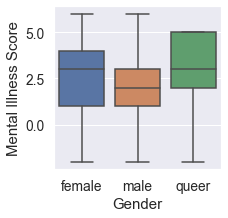

```python
#data visualization
fig, ax = plt.subplots(figsize=(3,3))
sns.set(font_scale=1.5)
ax = sns.boxplot(data = mental_survey,x = 'gender_cleaned', y = 'score')
ax.set_xlabel('Gender')
ax.set_ylabel('Mental Illness Score')
```

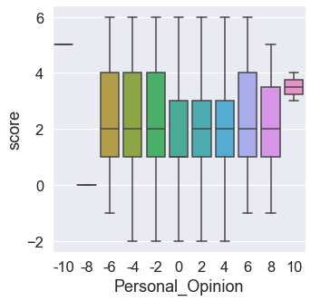

```python
fig, ax = plt.subplots(figsize=(5,5))
sns.boxplot(data = scores,x = 'Personal_Opinion', y = 'score')
```

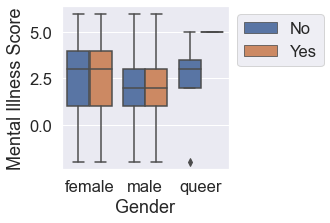

```python
fig, ax = plt.subplots(figsize=(3,3))
sns.set(font_scale=1.5)
ax = sns.boxplot(data = mental_survey,x = 'gender_cleaned', y = 'score', hue = 'remote_work')
ax.set_xlabel('Gender')
ax.set_ylabel('Mental Illness Score')
plt.legend(loc = 'best', bbox_to_anchor = (1, 1))
```

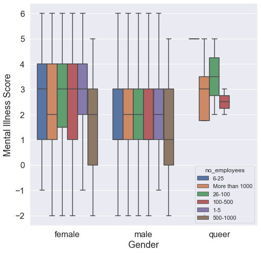

```python
fig, ax = plt.subplots(figsize=(8,8))
sns.set(font_scale=1)
ax = sns.boxplot(data = mental_survey,x = 'gender_cleaned', y = 'score', hue = 'no_employees')
ax.set_xlabel('Gender')
ax.set_ylabel('Mental Illness Score')
```

### 6.3 Question 3: What are the factors that most coincide with chronic physical illnesses and poor health in India?

*By Andy Wen*

To answer this question, I attempted to analyze key health indicators in India from 2012-2013. To do this, I first broke up the dataset into smaller dataframes consisting of each of the 26 key indicators and their respective statistics/questions in order to make analysis more feasible. After that, I selected several variables of interest that could be used as an indicator of chronic physical illness and poor health. These include the chronic illness indicator, acute illness indicator, and mortality indictor. All of these variables were standardized by population (per 100,000 people) which prevents different population sizes from influencing the analysis.

```python
import numpy as np
import matplotlib.pyplot as plt
import sklearn as sk
import seaborn as sns
```

```python
# A: Population Region [Sample Particulars]
population_region = indicators.iloc[: , 0:19]

# B: Household Characteristics
# Dependency Ratio is People Younger than 15 or Older than 64 over Working Age
household_characteristics = indicators.iloc[: , 19:39]

# C: Sex Ratio
sex_ratio = indicators.iloc[: , 39:46]

# D: Effective Literacy Rate
literacy = indicators.iloc[: , 46:55]

# E: Marriage
marriage = indicators.iloc[: , 55:73]

# F: Schooling Status
schooling_status = indicators.iloc[: , 73:91]

# G: Work Status
work_status = indicators.iloc[: , 91:109]

# H: Disability
disability = indicators.iloc[: , 109:118]

# I: Injury
injury = indicators.iloc[: , 118:145]

# J: Acute Illness
acute_illness = indicators.iloc[: , [0] + [i for i in range(145, 199)]]

# K: Chronic Illness
chronic_illness = indicators.iloc[: , [0] + [i for i in range(199, 289)]]

# L: Fertility
fertility = indicators.iloc[: , 290:328]

# M: Abortion
abortion = indicators.iloc[: , 328:346]

# N: Family Planning Practices (Cmw Aged 15-49 Years)
family_planning = indicators.iloc[: , [0] + [i for i in range(346, 382)]]

# O: Unmet Need For Family Planning
unmet_needs = indicators.iloc[: , 382:391]

# P: Ante Natal Care
natal_care = indicators.iloc[: , 391:424]

# Q: Delivery Care
delivery_care = indicators.iloc[: , 424:448]

# R: Post Natal Care
post_natal = indicators.iloc[: , 448:463]

# S: Janani Suraksha Yojana (JSY)
jsy = indicators.iloc[: , 463:472]

# T: Immunization, Vitamin A & Iron Supplement And Birth Weight
immunization = indicators.iloc[: , [0] + [i for i in range(472, 508)]]

# U: Childhood Diseases
childhood_diseases = indicators.iloc[: , 508:526]

# V: Breastfeeding And Supplementation
breastfeeding =  indicators.iloc[: , 526:562]

# W: Birth Registration
birth_registration = indicators.iloc[: , 562:568]

# X: Awareness On Hiv/Aids, Rti/Sti, Haf/Ors/Ort/Zinc And Ari/Pneumonia
awareness = indicators.iloc[: , 568:580]

# Y: Mortality
mortality = indicators.iloc[: , [0] + [i for i in range(580, 613)]]

# Z: Confidence Interval (95%) For Some Important Indicators
ci = indicators.iloc[: ,613:]
```

After creating these key indicator dataframes, I proceeded to select out areas of interest to investigate, specifically looking into demographics as well as other health indicators that could plausibly be connected to poor health. Among these include how rural or urban a region was since population density could feasibly affect poor health rates across a state of millions. To do this, I had to deal with the problem of having raw numbers instead of population proportions which I addressed by creating new variables “Percentage_Rural” and “Percentage_Urban” that showed the proportion of rural and urban within each state.

```python
population_region['Percentage_Rural'] = population_region['AA_Population_Rural']/population_region['AA_Population_Total']
population_region['Percentage_Urban'] = population_region['AA_Population_Urban']/population_region['AA_Population_Total']
population_region.head(3)
```

|  | State_Name | AA_Sample_Units_Total | AA_Sample_Units_Rural | AA_Sample_Units_Urban | AA_Households_Total | AA_Households_Rural | AA_Households_Urban | AA_Population_Total | AA_Population_Rural | AA_Population_Urban | ... | AA_Ever_Married_Women_Aged_15_49_Years_Rural | AA_Ever_Married_Women_Aged_15_49_Years_Urban | AA_Currently_Married_Women_Aged_15_49_Years_Total | AA_Currently_Married_Women_Aged_15_49_Years_Rural | AA_Currently_Married_Women_Aged_15_49_Years_Urban | AA_Children_12_23_Months_Total | AA_Children_12_23_Months_Rural | AA_Children_12_23_Months_Urban | Percentage_Rural | Percentage_Urban |
| --- | --- | --- | --- | --- | --- | --- | --- | --- | --- | --- | --- | --- | --- | --- | --- | --- | --- | --- | --- | --- | --- |
| 0 | Assam | 1784 | 1412 | 372 | 388853 | 319766 | 69087 | 1809610 | 1518639 | 290971 | ... | 291780.0 | 58150.0 | 325949.0 | 271954.0 | 53995.0 | 66840 | 58695 | 8145 | 0.839208 | 0.160792 |
| 1 | Bihar | 2356 | 1981 | 375 | 612684 | 568030 | 44654 | 3227867 | 2993906 | 233961 | ... | 550509.0 | 43090.0 | 577096.0 | 535700.0 | 41396.0 | 129530 | 121987 | 7543 | 0.927518 | 0.072482 |
| 2 | Chhattisgarh | 1255 | 926 | 329 | 287085 | 226554 | 60531 | 1264309 | 994416 | 269893 | ... | 197335.0 | 54608.0 | 233563.0 | 183215.0 | 50348.0 | 43422 | 35284 | 8138 | 0.786529 | 0.213471 |

3 rows × 21 columns

Next, I made a plot that showing the proportion breakdowns within each state which clearly indicates that a strong majority of each state’s population is located in rural areas with Bihar having the largest rural percentage and Madhya Pradesh having the smallest. Overall, this tells us that the vast majority of the areas sampled in India are rural.

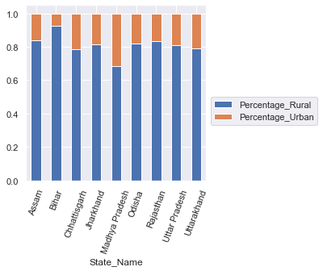

```python
# Percentage of Rural and Urban Population breakdown in Different Regions
population_region[['State_Name', 'Percentage_Rural', 'Percentage_Urban']].plot(x = 'State_Name', kind='bar', figsize = (4,4),stacked=True)
plt.xticks(rotation = 70)
plt.legend(loc = 'best', bbox_to_anchor = (1, 0.5))
plt.show()
```

```python
# Create Heatmap about Different Correlations
# Create some Percentages for Rural and Urban to Create Correlation Table
indicators['Percentage_Rural'] = indicators['AA_Population_Rural']/indicators['AA_Population_Total']
indicators['Percentage_Urban'] = indicators['AA_Population_Urban']/indicators['AA_Population_Total']

interesting_indicators = indicators[
    [
        "YY_Crude_Death_Rate_Cdr_Total_Person",
        "JJ_Persons_Suffering_From_Acute_Illness_Per_100000_Population_Any_Type_Of_Acute_Illness_Person_Total",
        "KK_Having_Diagnosed_For_Chronic_Illness_Per_100000_Population_Any_Kind_Of_Chronic_Illness_Person_Total",
        "UU_Children_Suffering_From_Diarrhoea_Total",
        "UU_Children_Suffering_From_Acute_Respiratory_Infection_Total",
        "UU_Children_Suffering_From_Fever_Total",
        "TT_Children_Aged_12_23_Months_Fully_Immunized_Total",
        "AA_Population_Total",
        "AA_Households_Total",
        "Percentage_Rural",
        "Percentage_Urban",
        "NN_Current_Usage_Any_Method_Total",
        "XX_Women_Who_Are_Aware_Of_Hiv_Aids_Total",
        "XX_Women_Who_Are_Aware_Of_Haf_Ors_Ort_Zinc_Total",
        "XX_Women_Who_Are_Aware_Of_Danger_Signs_Of_Ari_Pneumonia_Total",
        "OO_Unmet_Need_For_Spacing_Total",
        "OO_Unmet_Need_For_Limiting_Total",
        "OO_Total_Unmet_Need_Total",
        "HH_Prevalence_Of_Any_Type_Of_Disability_Per_100000_Population_Person_Total",
        "II_Number_Of_Injured_Persons_By_Type_Of_Treatment_Received_Per_100000_Population_Severe_Person_Total",
        "II_Number_Of_Injured_Persons_By_Type_Of_Treatment_Received_Per_100000_Population_Major_Person_Total",
        "II_Number_Of_Injured_Persons_By_Type_Of_Treatment_Received_Per_100000_Population_Minor_Male_Total",
        "FF_Children_Currently_Attending_School_Age_6_17_Years_Person_Total",
        "FF_Children_Attended_Before_Drop_Out_Age_6_17_Years_Person_Total",
        "DD_Person_Total"
    ]
]

interesting_indicators = interesting_indicators.rename(
    columns = {
        "YY_Crude_Death_Rate_Cdr_Total_Person": "Crude Death Rate",
        "JJ_Persons_Suffering_From_Acute_Illness_Per_100000_Population_Any_Type_Of_Acute_Illness_Person_Total": "People with Acute Illnesses (Per 100,000)",
        "KK_Having_Diagnosed_For_Chronic_Illness_Per_100000_Population_Any_Kind_Of_Chronic_Illness_Person_Total": "People with Chronic Illnesses (Per 100,000)",
        "UU_Children_Suffering_From_Diarrhoea_Total": "% of Children Suffering from Diarrhoea",
        "UU_Children_Suffering_From_Acute_Respiratory_Infection_Total": "% of Children Suffering from Acute Respiratory Infection",
        "UU_Children_Suffering_From_Fever_Total": "% of Children Suffering from Fevers",
        "TT_Children_Aged_12_23_Months_Fully_Immunized_Total": "% of Children (12-23 Months Old) Fully Immunized",
        "AA_Population_Total": 'Total Population',
        "AA_Households_Total": 'Total Households',
        "NN_Current_Usage_Any_Method_Total": '% of Population Using Family Planning Practices',
        "XX_Women_Who_Are_Aware_Of_Hiv_Aids_Total": "% of Women who are Aware of HIV/AIDs",
        "XX_Women_Who_Are_Aware_Of_Haf_Ors_Ort_Zinc_Total": "% of Women who are Aware of HAF/ORS/ORT/ZINC",
        "XX_Women_Who_Are_Aware_Of_Danger_Signs_Of_Ari_Pneumonia_Total": "% of Women who are Aware of ARI/Pneumonia",
        "OO_Unmet_Need_For_Spacing_Total": "% of People with Unmet Family Planning for Spacing",
        "OO_Unmet_Need_For_Limiting_Total": "% of People with Unmet Family Planning for Limiting",
        "OO_Total_Unmet_Need_Total": "% of People with Unmet Family Planning needs",
        "HH_Prevalence_Of_Any_Type_Of_Disability_Per_100000_Population_Person_Total": "Prevalence of Disabilities in Population (Per 100,000)",
        "II_Number_Of_Injured_Persons_By_Type_Of_Treatment_Received_Per_100000_Population_Severe_Person_Total": "Number of Severely Injured people (Per 100,000)",
        "II_Number_Of_Injured_Persons_By_Type_Of_Treatment_Received_Per_100000_Population_Major_Person_Total": "Number of People with Major Injuries (Per 100,000)",
        "II_Number_Of_Injured_Persons_By_Type_Of_Treatment_Received_Per_100000_Population_Minor_Male_Total": "Number of people with Minor Injuries (Per 100,000)",
        "FF_Children_Currently_Attending_School_Age_6_17_Years_Person_Total": "% of Age 6-17 Children in School",
        "FF_Children_Attended_Before_Drop_Out_Age_6_17_Years_Person_Total": "% of Children Attending School Before Dropping Out",
        "DD_Person_Total": "Literacy Rate (%)"
    }
)
```

In order to keep only the variables with the strongest correlations to the poor health indicators, I filtered arbitrarily to keep only those with at least a positive 0.5 correlation or below a -0.4 correlation for acute illnesses and crude death rates. I used 0.4 and -0.4 correlations, respectively, for chronic illnesses.

```python
# Correlations with Acute Illness
acute_illness_correlations = interesting_indicators.corrwith(interesting_indicators['People with Acute Illnesses (Per 100,000)']).sort_values(
ascending = False)

# Only Interested in the Most or Least Correlated (Filter by those with over positive 0.5 correlation or negative 0.4 correlation)
acute_illness_correlations[(acute_illness_correlations > 0.5) | (acute_illness_correlations < -0.4)]
```

```
People with Acute Illnesses (Per 100,000)                   1.000000
% of Women who are Aware of HAF/ORS/ORT/ZINC                0.736635
% of People with Unmet Family Planning needs                0.683947
% of People with Unmet Family Planning for Spacing          0.679826
% of Children Suffering from Fevers                         0.650650
% of Children Suffering from Acute Respiratory Infection    0.641381
% of People with Unmet Family Planning for Limiting         0.614471
Total Households                                            0.564632
Total Population                                            0.542569
Percentage_Urban                                           -0.434415
% of Population Using Family Planning Practices            -0.755170
dtype: float64
```

For acute illnesses, the strongest correlation exists at 0.736635 with % of women who are aware of HAF/ORS/ORT/ZINC. HAF/ORS/ORT/ZINC are all treatments used for illnesses/diseases such as diarrhea and an easy explanation for the strong correlation could be that those that live in areas with high amounts of acute illnesses may know these treatments as a result of lived experiences using them/seeing others use them to treat those illnesses.

Interestingly, we see that there is extremely strong negative correlation between using family planning practices and acute illness rates (-0.755170). There is also strong correlation between having unmet family planning needs and acute illness (0.683947, 0.679826, and 0.614471 respectively for general unmet family planning needs, unmet spacing needs, and unmet spacing needs). Since family planning is a form of healthcare that has immense impact on the livelihood, income, and health of a family, it does make sense that it has such a strong relationship with acute illness rates.

Total households and population are also moderately correlated with acute illness rates (>= 0.5) which can be a result of largely populated areas having more people that interact and can spread illnesses.

```python
# Correlations with Crude Death
crude_death_correlations = interesting_indicators.corrwith(interesting_indicators["Crude Death Rate"]).sort_values(ascending = False)

# Only Interested in the Most or Least Correlated (Filter by those with over positive 0.5 correlation or negative 0.4 correlation)
crude_death_correlations[(crude_death_correlations > 0.5) | (crude_death_correlations < -0.4)]
```

```
Crude Death Rate                                    1.000000
% of Children Suffering from Diarrhoea              0.601065
Total Households                                    0.580698
% of Women who are Aware of HAF/ORS/ORT/ZINC        0.535569
% of Age 6-17 Children in School                   -0.447991
% of Children (12-23 Months Old) Fully Immunized   -0.624803
dtype: float64
```

Crude death rates are most strongly correlated with % of Children Suffering from Diarrhea (0.601065) which is one of the leading causes of death, especially among children. Immunization rates (% of Children (12-23 Months Old) Fully Immunized ) are the most negatively correlated at -0.624803. These two things are likely related since immunization directly mitigates the risk of dying from and catching many illnesses/diseases such as diarrhea.

```python
# Correlations with Chronic Illnesses
chronic_correlations = interesting_indicators.corrwith(interesting_indicators['People with Chronic Illnesses (Per 100,000)']).sort_values(ascending = False)

# Only Interested in the Most or Least Correlated (Filter by those with over positive 0.4 correlation or negative 0.4 correlation)
chronic_correlations[(chronic_correlations > 0.4) | (chronic_correlations < -0.4)]
```

```
People with Chronic Illnesses (Per 100,000)           1.000000
Number of People with Major Injuries (Per 100,000)    0.483842
Number of people with Minor Injuries (Per 100,000)    0.457864
People with Acute Illnesses (Per 100,000)             0.443608
Percentage_Rural                                      0.431111
% of Children Suffering from Fevers                   0.421055
Percentage_Urban                                     -0.431111
% of Children (12-23 Months Old) Fully Immunized     -0.464744
dtype: float64
```

Chronic Illnesses are shown here to have the weakest correlations compared to the other illnesses since chronic illnesses have a strong genetic factor, completely unrelated to many of the variables polled. Nonetheless, high immunization rates are moderately negatively correlated with chronic illness rates while injury rates are moderately correlated. This makes sense since injuries can lead to longterm health issues as can not being immunized.

We also see that how rural a state is, is moderately correlated with acute and chronic illness rates.

After this, I looked into whether sex and region type (urban and rural breakdown) were related to different forms of physical illness/poor health. To do so, I created bar plots showing the number of people with each of the poor health indicators mentioned above (acute illnesses, chronic illnesses, and crude death rates) per 100,000 people within the 9 states. Within those bar plots, I would then analyze the differences in those poor health rates based on sex and region type.

Starting with acute illnesses, even when normalized for population, there was a disproportionately higher rate of acute illnesses among females than males which can be potentially due to reasons such as lack of availability in women’s healthcare. Lack of outreach to women about available healthcare options could also be attributed to this gap. When comparing rural and urban regions, rural regions lead in acute illness rates in all but one state, oftentimes by noticeable margins. This gap could be explained potentially by the side effects of low population density. Since there are less people living in rural areas, there are also likely less healthcare related resources (hospitals and doctors) within a close distance. Income disparity could also explain the gap since those living in rural areas tend to earn far less than those within the city meaning that healthcare resources may be less accessible due to costs or work obligations.

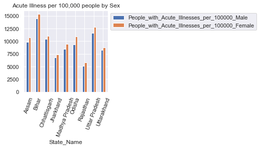

```python
# Acute Illness by Sex Plot
male_v_female_acute_illness = acute_illness
[
    ['State_Name',
     'JJ_Persons_Suffering_From_Acute_Illness_Per_100000_Population_Any_Type_Of_Acute_Illness_Male_Total',
     'JJ_Persons_Suffering_From_Acute_Illness_Per_100000_Population_Any_Type_Of_Acute_Illness_Female_Total'
    ]
]

male_v_female_acute_illness = male_v_female_acute_illness.rename(
    columns = {'JJ_Persons_Suffering_From_Acute_Illness_Per_100000_Population_Any_Type_Of_Acute_Illness_Male_Total': "People_with_Acute_Illnesses_per_100000_Male",
               'JJ_Persons_Suffering_From_Acute_Illness_Per_100000_Population_Any_Type_Of_Acute_Illness_Female_Total': "People_with_Acute_Illnesses_per_100000_Female"
              }
)

male_v_female_acute_illness.plot(x = 'State_Name',
                                 y = ["People_with_Acute_Illnesses_per_100000_Male",
                                      "People_with_Acute_Illnesses_per_100000_Female"],
                                 kind = 'bar', figsize = (3,3),
                                 title = 'Acute Illness per 100,000 people by Sex')

plt.xticks(rotation = 70)
plt.legend(loc = 'best', bbox_to_anchor = (1, 1))
plt.show()
```

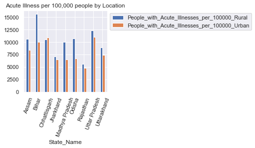

```python
# Acute Illness Rural/Urban Distribution Plot
rural_v_urban_acute_illness = acute_illness
[
    ['State_Name',
     'JJ_Persons_Suffering_From_Acute_Illness_Per_100000_Population_Any_Type_Of_Acute_Illness_Person_Rural',
     'JJ_Persons_Suffering_From_Acute_Illness_Per_100000_Population_Any_Type_Of_Acute_Illness_Male_Urban'
    ]
]

rural_v_urban_acute_illness = rural_v_urban_acute_illness.rename(
    columns = {'JJ_Persons_Suffering_From_Acute_Illness_Per_100000_Population_Any_Type_Of_Acute_Illness_Person_Rural': "People_with_Acute_Illnesses_per_100000_Rural",
               'JJ_Persons_Suffering_From_Acute_Illness_Per_100000_Population_Any_Type_Of_Acute_Illness_Male_Urban': "People_with_Acute_Illnesses_per_100000_Urban"})

rural_v_urban_acute_illness.plot(x = 'State_Name',
                                 y = ["People_with_Acute_Illnesses_per_100000_Rural",
                                      "People_with_Acute_Illnesses_per_100000_Urban"],
                                 kind = 'bar', figsize = (3,3),
                                 title = 'Acute Illness per 100,000 people by Location')
plt.xticks(rotation = 70)
plt.legend(loc = 'best', bbox_to_anchor = (1, 1))
plt.show()
```

Applying the same strategy with bar plots onto chronic illnesses, we see that women seem to also be disproportionately impacted by chronic illnesses. This can be seen in all of the states and can potentially be for similar reasons as acute illnesses such as lack of availability/accessibility in women’s healthcare. There’s far less of a noticeable trend when looking at chronic illness rates by region. While a majoriy of states show that cities have higher chronic illness rates, others show rural areas leading. This can be potentially attributed to chronic illnesses having a large genetics factor that would be unaffected by income disparity and healthcare resource proximity despite those factors still applying.

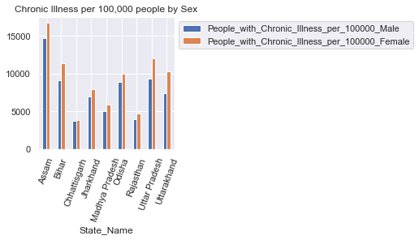

```python
# Chronic Illness by Sex Plot
male_v_female_chronic_illness = chronic_illness[['State_Name',
                                                 'KK_Having_Diagnosed_For_Chronic_Illness_Per_100000_Population_Any_Kind_Of_Chronic_Illness_Male_Total',
                                                 'KK_Having_Diagnosed_For_Chronic_Illness_Per_100000_Population_Any_Kind_Of_Chronic_Illness_Female_Total']]

male_v_female_chronic_illness = male_v_female_chronic_illness.rename(
    columns = {'KK_Having_Diagnosed_For_Chronic_Illness_Per_100000_Population_Any_Kind_Of_Chronic_Illness_Male_Total': "People_with_Chronic_Illness_per_100000_Male",
               'KK_Having_Diagnosed_For_Chronic_Illness_Per_100000_Population_Any_Kind_Of_Chronic_Illness_Female_Total': "People_with_Chronic_Illness_per_100000_Female"
              }
)

male_v_female_chronic_illness.plot(x = 'State_Name',
                                   y = ["People_with_Chronic_Illness_per_100000_Male",
                                        "People_with_Chronic_Illness_per_100000_Female"],
                                   kind = 'bar', figsize = (3,3),
                                   title = 'Chronic Illness per 100,000 people by Sex')
plt.xticks(rotation = 70)
plt.legend(loc = 'best', bbox_to_anchor = (1, 1))
plt.show()
```

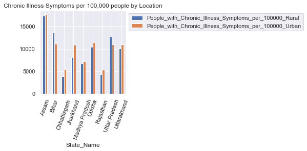

```python
# Chronic illnesses Rural/Urban Distribution Plot
rural_v_urban_chronic_illness = chronic_illness[['State_Name',
                                                 'KK_Having_Any_Kind_Of_Symptoms_Of_Chronic_Illness_Per_100000_Population_Person_Rural',
                                                 'KK_Having_Any_Kind_Of_Symptoms_Of_Chronic_Illness_Per_100000_Population_Person_Urban']]

rural_v_urban_chronic_illness = rural_v_urban_chronic_illness.rename(columns = {'KK_Having_Any_Kind_Of_Symptoms_Of_Chronic_Illness_Per_100000_Population_Person_Rural': "People_with_Chronic_Illness_Symptoms_per_100000_Rural",
                                                                                'KK_Having_Any_Kind_Of_Symptoms_Of_Chronic_Illness_Per_100000_Population_Person_Urban': "People_with_Chronic_Illness_Symptoms_per_100000_Urban"})
rural_v_urban_chronic_illness.plot(x = 'State_Name',
                                   y = ["People_with_Chronic_Illness_Symptoms_per_100000_Rural",
                                        "People_with_Chronic_Illness_Symptoms_per_100000_Urban"],
                                   kind = 'bar', figsize = (3,3),
                                   title = 'Chronic Illness Symptoms per 100,000 people by Location')
plt.xticks(rotation = 70)
plt.legend(loc = 'best', bbox_to_anchor = (1, 1))
plt.show()
```

Lastly, looking at crude death rates, we see that men seem to have disproportionately rates of death. This can be seen in all of the states and can potentially be a result of different factors such as suicide rates which as Davis’ analysis shows, tends to be significantly higher among men. Rural areas also seem to have much higher death rates compared to their urban counterparts in every state. Likely causes of this are lack of healthcare availability as a result of lower population density and/or income disparity.

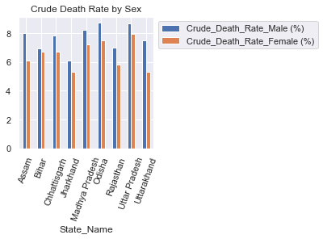

```python
# Mortality by Sex Plot
male_v_female_mortality_illness = mortality
[
    ['State_Name',
     'YY_Crude_Death_Rate_Cdr_Total_Male',
     'YY_Crude_Death_Rate_Cdr_Total_Female'
    ]
]

male_v_female_mortality_illness = male_v_female_mortality_illness.rename(
    columns = {'YY_Crude_Death_Rate_Cdr_Total_Male': "Crude_Death_Rate_Male (%)",
               'YY_Crude_Death_Rate_Cdr_Total_Female': "Crude_Death_Rate_Female (%)"
              }
)

male_v_female_mortality_illness.plot(x = 'State_Name',
                                     y = ["Crude_Death_Rate_Male (%)",
                                          "Crude_Death_Rate_Female (%)"],
                                     kind = 'bar', figsize = (3,3),
                                     title = 'Crude Death Rate by Sex')

plt.xticks(rotation = 70)
plt.legend(loc = 'best', bbox_to_anchor = (1, 1))
plt.show()
```

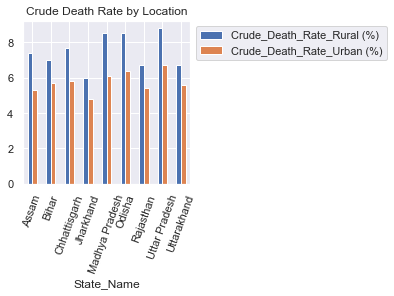

```python
# Mortality Rural/Urban Distribution Plot
rural_v_urban_mortality = mortality
[
    ['State_Name',
     'YY_Crude_Death_Rate_Cdr_Rural_Person',
     'YY_Crude_Death_Rate_Cdr_Urban_Person'
    ]
]

rural_v_urban_mortality = rural_v_urban_mortality.rename(
    columns = {'YY_Crude_Death_Rate_Cdr_Rural_Person': "Crude_Death_Rate_Rural (%)",
               'YY_Crude_Death_Rate_Cdr_Urban_Person': "Crude_Death_Rate_Urban (%)"
              }
)

rural_v_urban_mortality.plot(x = 'State_Name',
                             y = ["Crude_Death_Rate_Rural (%)",
                                  "Crude_Death_Rate_Urban (%)"],
                             kind = 'bar', figsize = (3,3),
                             title = 'Crude Death Rate by Location')

plt.xticks(rotation = 70)
plt.legend(loc = 'best', bbox_to_anchor = (1, 1))
plt.show()
```

Looking into family planning usage due to its strong negative correlation with acute illness rates, we see that rural areas tend to use family planning less often compared to urban areas which reinforces our hypothesis that healthcare accessibility may be lower in rural regions. We performed this analysis using a bar plot similar to the plots above.

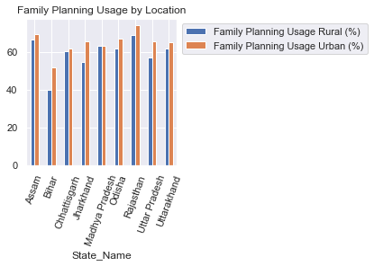

```python
# Family Planning Rural/Urban Distribution Plot
rural_v_urban_family_planning = family_planning[['State_Name',
                                                  'NN_Current_Usage_Any_Method_Rural',
                                                  'NN_Current_Usage_Any_Method_Urban']]

rural_v_urban_family_planning = rural_v_urban_family_planning.rename(columns = {'NN_Current_Usage_Any_Method_Rural': "Family Planning Usage Rural (%)",
                                                                                'NN_Current_Usage_Any_Method_Urban': "Family Planning Usage Urban (%)"})
rural_v_urban_family_planning.plot(x = 'State_Name',
                                   y = ["Family Planning Usage Rural (%)",
                                        "Family Planning Usage Urban (%)"],
                                   kind = 'bar', figsize = (3,3),
                                   title = 'Family Planning Usage by Location')
plt.xticks(rotation = 70)
plt.legend(loc = 'best', bbox_to_anchor = (1, 1))
plt.show()
```

Looking into immunization in children due to its moderately strong negative correlation with crude death rates, we see that rural areas tend to have lower immunization rates compared to their urban counterparts. This can be attributed to lack of healthcare accessibility once again.

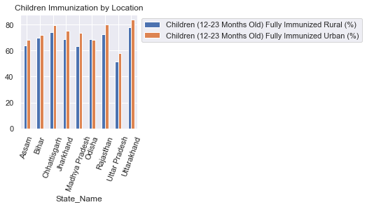

```python
# Immunization Rural/Urban Distribution Plot
rural_v_urban_immunization = immunization[['State_Name',
                                           'TT_Children_Aged_12_23_Months_Fully_Immunized_Rural',
                                           'TT_Children_Aged_12_23_Months_Fully_Immunized_Urban']]

rural_v_urban_immunization = rural_v_urban_immunization.rename(columns = {'TT_Children_Aged_12_23_Months_Fully_Immunized_Rural': "Children (12-23 Months Old) Fully Immunized Rural (%)",
                                                                          'TT_Children_Aged_12_23_Months_Fully_Immunized_Urban': "Children (12-23 Months Old) Fully Immunized Urban (%)"})
rural_v_urban_immunization.plot(x = 'State_Name',
                                y = ["Children (12-23 Months Old) Fully Immunized Rural (%)",
                                     "Children (12-23 Months Old) Fully Immunized Urban (%)"],
                                kind = 'bar', figsize = (3,3),
                                title = 'Children Immunization by Location')
plt.xticks(rotation = 70)
plt.legend(loc = 'best', bbox_to_anchor = (1, 1))
plt.show()
```

Overall, lack of family planning and low immunization rates among children seem to be the 2 factors most associated with poor health and physical health illness among those in India. These disparities exist in rural areas which can be a strong attributing factor to their higher crude death rates and higher acute illness rates.

## 7 Conclusions

On a global scale, men and the elderly are at heightened risk for suicide, and this can’t necessarily be explained by the availability of various mental health resources or lack thereof. Some potential explanations are that traditional views surrounding masculinity encourage men not to be communicative or open about their mental health problems [2] and while women attempt suicide more than men, men are more likely to employ deadlier methods such as firearms [3]. Some potential explanations for higher suicide rates among the elderly are grief over lost loved ones, loss of self-sufficiency, chronic illness/pain, as well as cognitive impairment [4]. These explanation shine a light on the fact that ways to effectively target a specific medical issue might not always come via direct intervention, but rather targeting improvements in other areas that can serve as risk factors for the main problem. For example, establishing effective grief counseling for the elderly might have a positive impact on their suicide rates or establishing stricter gun laws might force men to seek less-deadly methods for attempting suicide.

In India, rural areas are more prone to poor physical health in the form of higher crude death rates and higher acute illness rates. Some potential explanations, as discussed above, include lower immunization rates among children as well as a lack of availability in family planning. Both of these factors were shown to have strong correlations with either crude death rates, chronic illness rates, and/or acute illness rates. We also see that rural areas have lower immunization rates and lower family planning usage which helps to explain this disparity. Immunization directly helps prevent diseases and illnesses such as diarrhea which can be incredibly deadly, especially for children which explains why death rates may be higher in certain areas like rural regions. Meanwhile family planning is a critical form of healthcare that can impact the livelihood of an entire family and thus their health. A lack of accessibility in healthcare such as family planning can be a reason why certain areas have poorer health. Overall, these explanations present an opportunity to improve the physical livelihoods of many, especially in India. Pushing for greater healthcare accessibility in rural regions throughout the country can help increase immunization rates and family planning usage which are both related to poor physical health. In addition, we see that women are disproportionately impacted by acute illnesses and chronic illnesses. Increasing outreach towards women and others in rural areas can be a way to go about improving physical health in India. Lastly, we saw that men have higher crude death rates which can be partially explained by much of the mental health analysis done above.

In terms of mental health, it is clear that company benefits has a impact on their employee’s mental status and thus their potential work performance. There is clearly a gap between different countries, which I think is an important notice and that it will be improtant to close the gap. Moreover, although personal opinions have little to do with the mental score, the actual benefit is improtant. By noticing the difference among demographic and different companies, the dataset also shows that different companies may have different requests and emphasis on the mental health service they would want to provide to the employees.

There are always some external predictors that are avoidable or have the potential of being amended to improve the results such as mental illness, suicide, or illness. It can be information for individuals to take care of themselves and insights for lawmakers and researchers to look into to make social changes that benefit all people.

## 8 Recommendations to stakeholder(s)

On a broad scale, suicide interventions should be developed that place special emphasis on messaging that targets men and the elderly. Additionally, the lack of correlation between the quantity mental health resources and suicide rates suggest that the effectiveness of our facilities, mental health workers, and developed interventions is based on their preparedness and ability to provide effective care rather than their quantity. Instead of providing funding for more mental health resources on a global scale, organizations should advocate for ensuring that the existing structures in place have enough resources to provide quality care and implement effective anti-suicide prevention techniques. Additionally, more research emphasis should be placed on the systemic causes of males and the elderly generally having higher suicide rates and developing interventions that effectively target these demographics.

However, some of limitations of the above suicide analyses should be addressed. While the countries are grouped by continent, it is entirely possible that grouping the countries by other indicators is more appopriate to diagnose trends (such as first world, second world, and third world). Because of the broad nature of this analysis, the variability between countries from the same continent is not accounted for. More research needs to be done in order to examine the cultural and economic differences in different countries and how they play a role in suicide. Stakeholders should delve deeper into these factors to develop nuanced interventions that can be tailored for specific cultures/regions/and demographics.

Increasing immunization rates for children should be a top priority for any government (especially India’s government) looking to improve physical health among the population. There should be an additional emphasis towards targeting rural regions where immunization rates and overall healthcare availability may be lacking. This can be done by opening more clinics in areas that are far away from any currently available option. Increasing accessibility also means making it price accessible which may not be the case in rural areas where the average income may be lower than urban areas. Also, increasing awareness of ORS and Zinc through advertisement or school can be a great way to decrease crude death rates since those are treatments for diarrhea. One limitation is that this analysis uses data that is nearly a decade old and specific to 9 states that make up a minority of India’s population. Thus, performing this same analysis on a more updated and wide spanning survey can be a way to get the best possible results. Stakeholders that hope to use these solutions outside of India also need to be aware of how different the demographic/socio-economic factors may look in their own areas compared to India. India’s rural population percentage is incredibly high compared to its urban population which can explain some of the results seen. Stakeholders will need to tailor their actions to the area they hope to apply these solutions.

Similarly, increasing accessibility of family planning practices as well as general healthcare can be a great way for governments to improve physical health as well. Opening clinics in remote areas and improving access can cut down acute illness rates, especially in rural regions. Having the option of using family planning practices impacts everything from health to income within the family and making sure that it is available is a great step towards improving physical and potentially mental health. This recommendation faces the same issues as the one above. It is based on an outdated data source and is only applicable to India.

Making healthcare more accessible for women can also help with cutting down on chronic/acute illness rates since we see that women have higher rates of chronic/acute illnesses compared to men. This can be done through opening more clinics/hospitals in remote areas as well as advertising/performing outreach about women’s healthcare. This recommendation also faces the same issues that the above recommendations face. It is based on a decade old data source and is really only applicable to India. A stakeholder would have to customize these solutions based on the demographics and socio-economic realities in their countries/areas of interest.

For mental health, it is important to standardize some of the benefits and programs working environment should provide to people and narrow the gaps between the mental health service in different countries. Also, acknowledging the gender, age, and race difference and how all demographic difference play in the role of how comfortable people feel in the working environment and make explicit effort to make an inclusive environment that people comfortable opening up to someone when they need the help.

From the perspective of the company, it is true that mental disorder and illness can be interruptive to people’s working environment. Thus It will beneficial for the company as well if the companies invest in a strong mental health benefit system. In a way, it can be attractive to people and establish the productivity and healthy environment for all.

## References

[1] “Top 10 Most Common Health Issues.” Top 10 Most Comment Health Issues - Common Senior Health Issues - Senior Health - University of Rochester Medical Center, www.urmc.rochester.edu/senior-health/common-issues/top-ten.aspx.

[2] “Why Are Suicides So High Amongst Men?” Priory, Priory Group, www.priorygroup.com/blog/why-are-suicides-so-high-amongst-men.

[3] Schumacher, Helene. “Why More Men than Women Die by Suicide.” BBC Future, BBC, 17 Mar. 2019, www.bbc.com/future/article/20190313-why-more-men-kill-themselves-than-women.

[4] “Suicide and Older Adults: What You Should Know.” The National Council on Aging, 7 Sept. 2021, ncoa.org/article/suicide-and-older-adults-what-you-should-know.